# R4DS_2E_exploratoryDataAnalysis

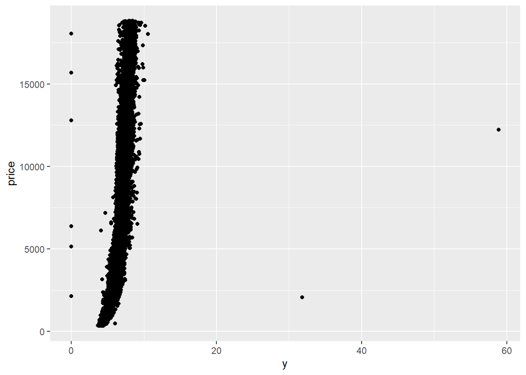

```r
ggplot(diamonds, aes(y, price)) +
  geom_point()
```

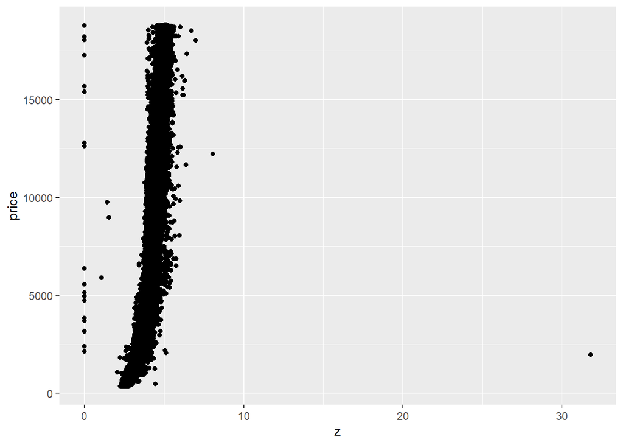

```r
ggplot(diamonds, aes(z, price)) +
  geom_point()
```

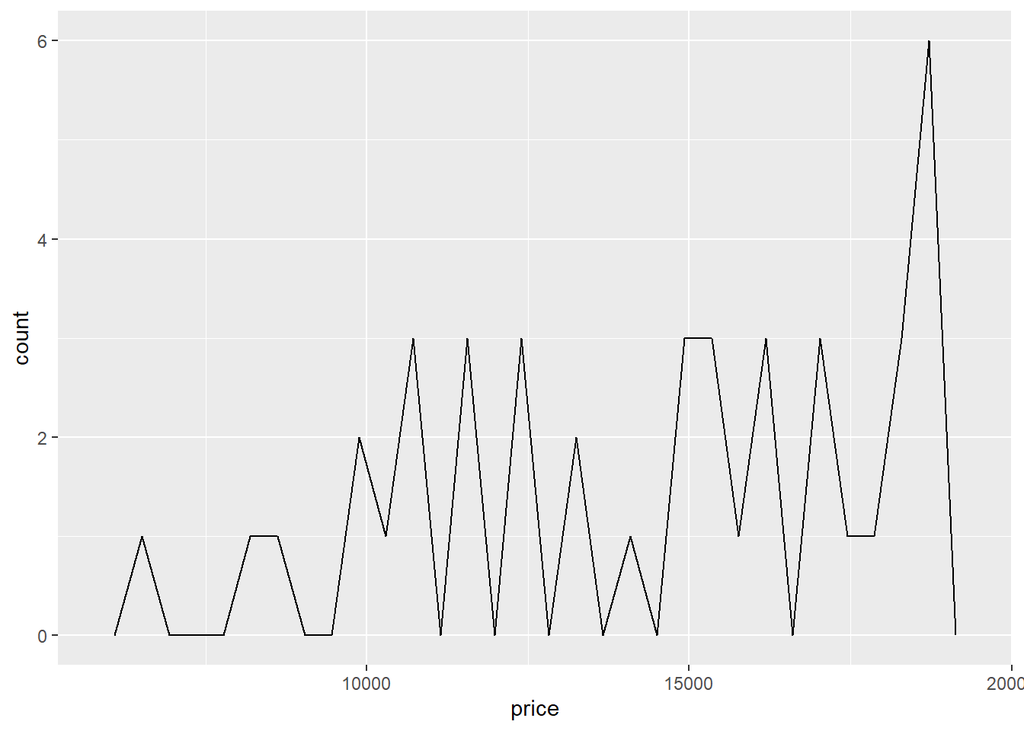

```r
# I'm going to define very large diamonds as diamonds that have a length of greater than 9mm. I'm going to define small diamonds as those that have a length of less than 4 mm but also I'm going to remove obvious data entry errors of those of 0mm

vlarge_diamonds <- diamonds |>
  filter(x >= 9)
small_diamonds <- diamonds |>
  filter(between(x, 0.5, 4))

ggplot(vlarge_diamonds, aes(x = price)) +
  geom_freqpoly()
```

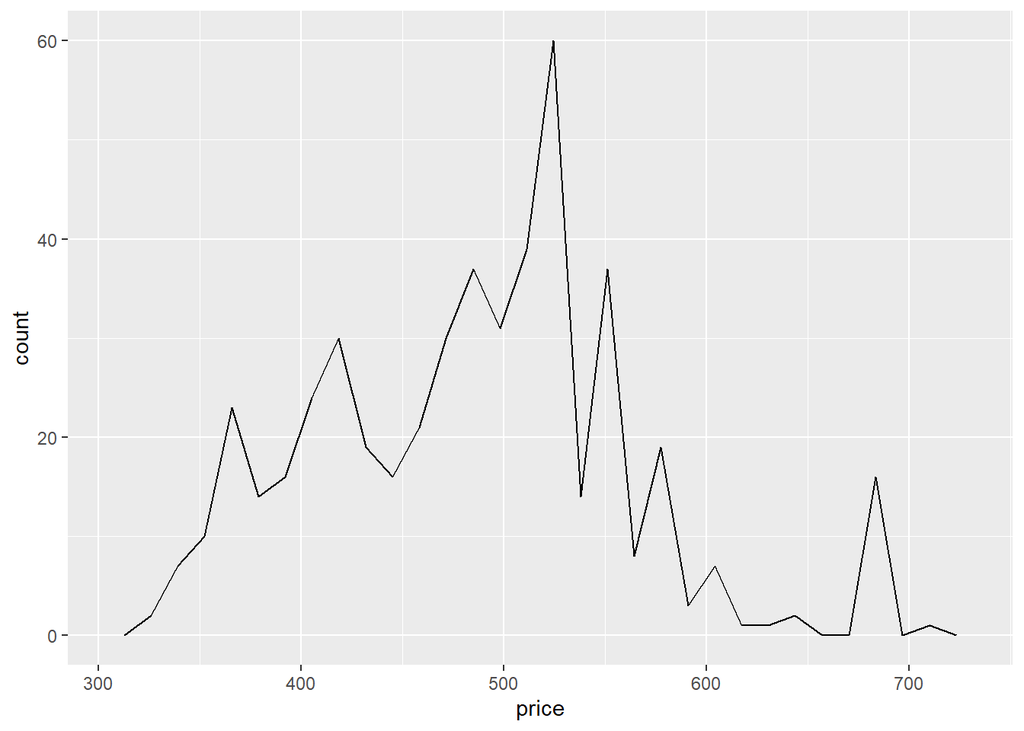

```r
# very large diamonds are much more variable in their pricing, with a greater spike in count near the high end prices

ggplot(small_diamonds, aes(x = price)) +
  geom_freqpoly()
```

```r
# Small diamonds don't break the $750 limit and seem to be significantly less variable in terms of their pricing with more diamonds at the ~$500 range.

# The results dont seem that suprising.
```

4. Combine two of the techniques you’ve learned to visualize the combined distribution of cut, carat, and price.

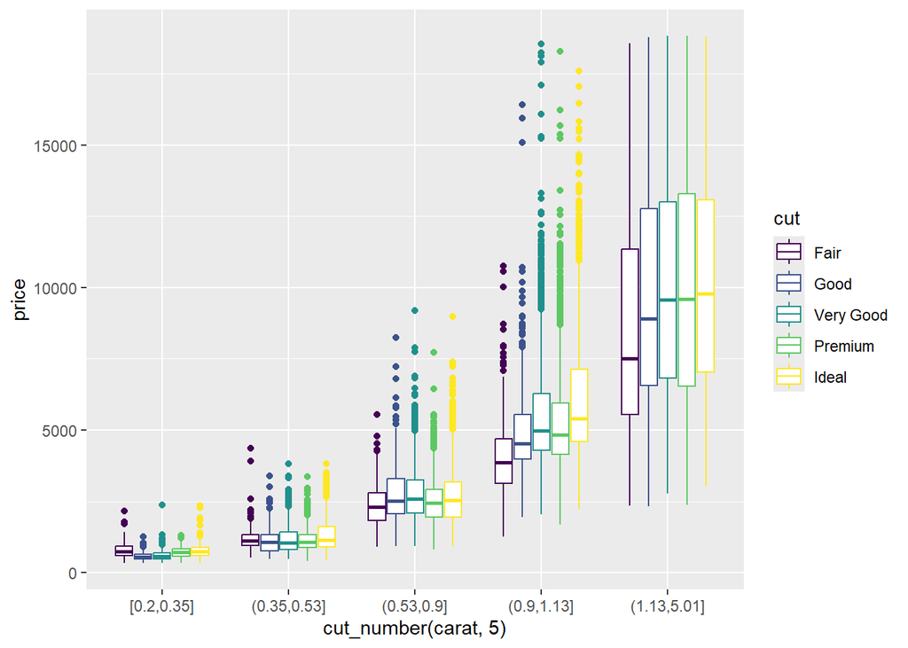

```r
# Using something similar to Chunk 18
ggplot(diamonds, aes(x = cut_number(carat, 5), y = price, colour = cut)) +
  geom_boxplot()
```

5. Two dimensional plots reveal outliers that are not visible in one dimensional plots. For example, some points in the following plot have an unusual combination of x and y values, which makes the points outliers even though their x and y values appear normal when examined separately. Why is a scatterplot a better display than a binned plot for this case?

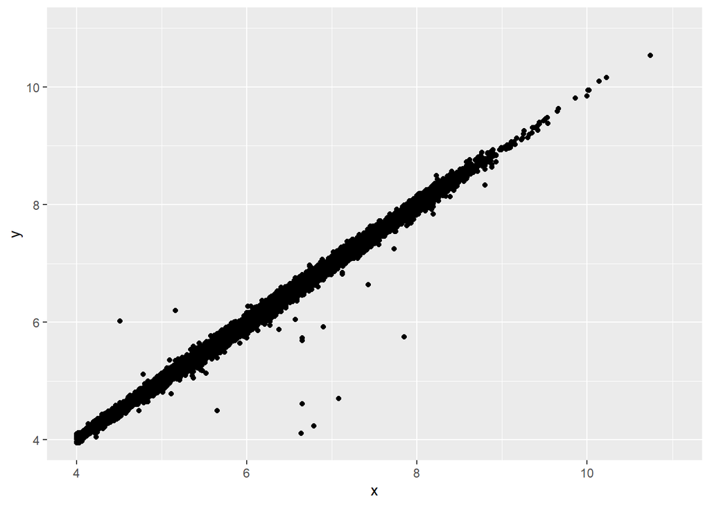

```r
diamonds |>
  filter(x >= 4) |>
  ggplot(aes(x = x, y = y)) +
  geom_point() +
  coord_cartesian(xlim = c(4, 11), ylim = c(4, 11))
```

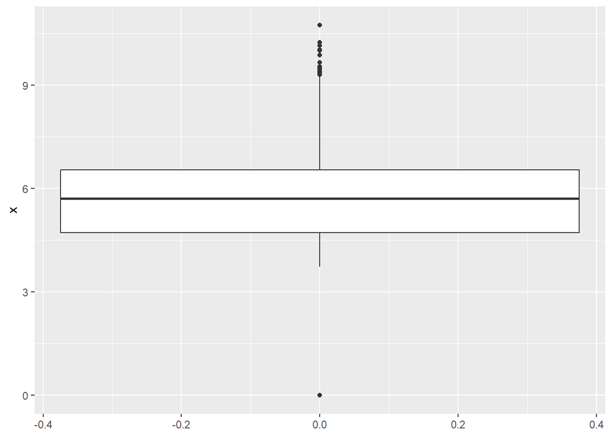

```r
# Examining them separately to see:
ggplot(diamonds, aes(y = x)) +
  geom_boxplot()
```

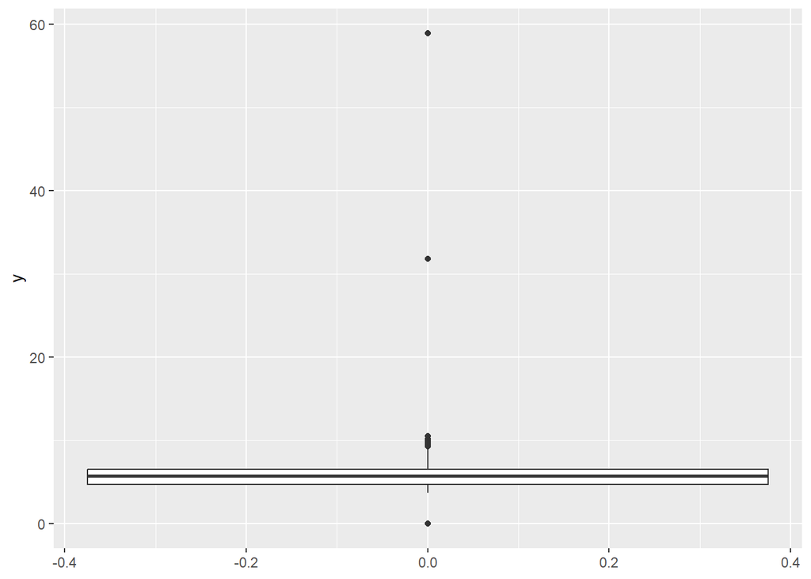

```r
ggplot(diamonds, aes(y = y)) +
  geom_boxplot()
```